# Instagram Reels Posting Strategies

#Load Packages

```r
library(tidyverse)
library(ISLR)
library(dplyr)
```

#Load Dataset

```r
insta_data <- read.csv('/Users/ggsantos/Documents/Data_Python_folder/pandas_projects/Instagram Reels(testing_data).csv')
View(insta_data)
```

```r
library(readr)
instagram_cleaner <- insta_data%>%
  select(Profile.URL,
         Post.ID,
         Reel.URL,
         Likes,
         total_replies = Raw.Replies,
         v_length = Video.Length..seconds.,
         post_time = Post.Time..EST.,
         Month,
         Cumulative.Date,
         Day.of.Week,
         View.Count,
         Followers

  )
instagram_cleaner
```

| Profile.URL | Post.ID | Reel.URL | Likes | total_replies | v_length | post_time | Month | Cumulative.Date | Day.of.Week | View.Count | Followers |
| --- | --- | --- | --- | --- | --- | --- | --- | --- | --- | --- | --- |
| https://www.instagram.com/ggsaintos/reels/ | DC47pgwy0Dc | https://www.instagram.com/ggsaintos/reel/DC47pgwy0Dc/ | 764 | 59 | 37.933333 | 12:36:18 | November | 2024-11-28 | Thursday | 13100 | 25361 |
| https://www.instagram.com/ggsaintos/reels/ | C-gSNwSJPKD | https://www.instagram.com/ggsaintos/reel/C-gSNwSJPKD/ | 56178 | 81 | 32.233333 | 17:38:49 | August | 2024-08-10 | Saturday | 777000 | 25361 |
| https://www.instagram.com/ggsaintos/reels/ | C0shKRfoJSg | https://www.instagram.com/ggsaintos/reel/C0shKRfoJSg/ | 553536 | 76 | 21.941405 | 14:28:44 | December | 2023-12-24 | Sunday | 4800000 | 25361 |
| https://www.instagram.com/ggsaintos/reels/ | DCsBNwUSJhJ | https://www.instagram.com/ggsaintos/reel/DCsBNwUSJhJ/ | 2969 | 80 | 42.366667 | 2:06:01 | November | 2024-11-29 | Friday | 47900 | 25361 |
| https://www.instagram.com/ggsaintos/reels/ | DBkffTgN5Em | https://www.instagram.com/ggsaintos/reel/DBkffTgN5Em/ | 254851 | 92 | 51.200000 | 22:23:39 | October | 2024-10-25 | Friday | 1900000 | 25361 |
| https://www.instagram.com/ggsaintos/reels/ | DAZVGvMJ2oN | https://www.instagram.com/ggsaintos/reel/DAZVGvMJ2oN/ | 257 | 47 | 29.866667 | 17:40:00 | September | 2024-09-26 | Thursday | 6719 | 25361 |
| https://www.instagram.com/ggsaintos/reels/ | DAHTgEsJF_T | https://www.instagram.com/ggsaintos/reel/DAHTgEsJF_T/ | 388 | 68 | 67.266667 | 17:42:04 | September | 2024-09-19 | Thursday | 10500 | 25361 |
| https://www.instagram.com/ggsaintos/reels/ | C_1L8-bpjKq | https://www.instagram.com/ggsaintos/reel/C_1L8-bpjKq/ | 229415 | 120 | 35.873377 | 16:49:32 | September | 2024-09-12 | Thursday | 2000000 | 25361 |
| https://www.instagram.com/ggsaintos/reels/ | C_l3j97tvZg | https://www.instagram.com/ggsaintos/reel/C_l3j97tvZg/ | 1866 | 82 | 49.233333 | 18:00:00 | September | 2024-09-06 | Friday | 22700 | 25361 |
| https://www.instagram.com/ggsaintos/reels/ | C_TjG6QSLTA | https://www.instagram.com/ggsaintos/reel/C_TjG6QSLTA/ | 518 | 50 | 12.599999 | 10:54:50 | September | 2024-09-02 | Monday | 25400 | 25361 |

[output cut: 990 more lines]

#Cleaning Data Cleaning the Data before Visualization and training

We must first filter out outliers and certain conditions in View counts that may cause a skew in the data

```r
instagram <- instagram_cleaner %>%
  drop_na(Likes)
```

#Outliers should be filtered out as well to avoid skewing of data

```r
z_scores <- scale(instagram$View.Count)
outliers <- abs(z_scores) > 3

Q1 <- quantile(instagram$View.Count, 0.25)
Q3 <- quantile(instagram$View.Count, 0.75)
IQR <- Q3 - Q1
outliers <- instagram$View.Count < (Q1 - 1.5 * IQR) | instagram$View.Count > (Q3 + 1.5 * IQR)

instagram_1 <- instagram[!outliers, ]

instagram_1
```

|  | Profile.URL | Post.ID | Reel.URL | Likes | total_replies | v_length | post_time | Month | Cumulative.Date | Day.of.Week | View.Count | Followers |
| --- | --- | --- | --- | --- | --- | --- | --- | --- | --- | --- | --- | --- |
| 1 | https://www.instagram.com/ggsaintos/reels/ | DC47pgwy0Dc | https://www.instagram.com/ggsaintos/reel/DC47pgwy0Dc/ | 764 | 59 | 37.933333 | 12:36:18 | November | 2024-11-28 | Thursday | 13100 | 25361 |
| 4 | https://www.instagram.com/ggsaintos/reels/ | DCsBNwUSJhJ | https://www.instagram.com/ggsaintos/reel/DCsBNwUSJhJ/ | 2969 | 80 | 42.366667 | 2:06:01 | November | 2024-11-29 | Friday | 47900 | 25361 |
| 6 | https://www.instagram.com/ggsaintos/reels/ | DAZVGvMJ2oN | https://www.instagram.com/ggsaintos/reel/DAZVGvMJ2oN/ | 257 | 47 | 29.866667 | 17:40:00 | September | 2024-09-26 | Thursday | 6719 | 25361 |
| 7 | https://www.instagram.com/ggsaintos/reels/ | DAHTgEsJF_T | https://www.instagram.com/ggsaintos/reel/DAHTgEsJF_T/ | 388 | 68 | 67.266667 | 17:42:04 | September | 2024-09-19 | Thursday | 10500 | 25361 |
| 9 | https://www.instagram.com/ggsaintos/reels/ | C_l3j97tvZg | https://www.instagram.com/ggsaintos/reel/C_l3j97tvZg/ | 1866 | 82 | 49.233333 | 18:00:00 | September | 2024-09-06 | Friday | 22700 | 25361 |
| 10 | https://www.instagram.com/ggsaintos/reels/ | C_TjG6QSLTA | https://www.instagram.com/ggsaintos/reel/C_TjG6QSLTA/ | 518 | 50 | 12.599999 | 10:54:50 | September | 2024-09-02 | Monday | 25400 | 25361 |
| 11 | https://www.instagram.com/ggsaintos/reels/ | C_OzPIdp9ee | https://www.instagram.com/ggsaintos/reel/C_OzPIdp9ee/ | 37309 | 92 | 62.249841 | 22:00:28 | August | 2024-08-28 | Wednesday | 302000 | 25361 |
| 16 | https://www.instagram.com/justrandomeveryday/reels/ | DDFq6DGzj4w | https://www.instagram.com/justrandomeveryday/reel/DDFq6DGzj4w/ | 372 | 66 | 60.066667 | 15:04:14 | December | 2024-12-02 | Monday | 18800 | 273559 |
| 17 | https://www.instagram.com/justrandomeveryday/reels/ | DC_VAvOxIAY | https://www.instagram.com/justrandomeveryday/reel/DC_VAvOxIAY/ | 11276 | 67 | 13.199999 | 3:55:26 | November | 2024-11-30 | Saturday | 312000 | 273559 |
| 18 | https://www.instagram.com/justrandomeveryday/reels/ | DC3ZWSjR9NQ | https://www.instagram.com/justrandomeveryday/reel/DC3ZWSjR9NQ/ | 5220 | 77 | 52.766667 | 18:38:00 | November | 2024-11-27 | Wednesday | 50900 | 273559 |

[output cut: 909 more lines]

Now in order to properly visualize time we must convert the time to the proper formatting and afterwards we can categorize each time by time_category

```r
unique(instagram_1$post_time)
```

```
  [1] "12:36:18" "2:06:01"  "17:40:00" "17:42:04" "18:00:00" "10:54:50" "22:00:28" "15:04:14"
  [9] "3:55:26"  "18:38:00" "18:51:37" "17:05:52" "2:03:26"  "21:27:45" "16:09:01" "3:00:15"
 [17] "13:34:32" "12:00:52" "14:00:00" "13:00:00" "12:00:00" "13:47:19" "14:31:55" "11:31:38"
 [25] "19:39:48" "14:37:50" "10:02:06" "14:40:58" "11:19:18" "19:29:09" "22:08:18" "16:35:42"
 [33] "15:40:25" "15:29:56" "18:50:01" "21:09:33" "4:04:49"  "7:42:48"  "0:02:24"  "14:24:56"
 [41] "18:37:26" "18:37:39" "23:49:55" "15:29:51" "12:20:23" "18:38:01" "4:44:32"  "13:07:11"
 [49] "14:15:37" "13:33:04" "16:31:43" "13:58:17" "12:53:35" "13:18:56" "13:22:38" "15:01:32"
 [57] "12:43:19" "19:39:18" "13:11:56" "10:44:38" "16:08:27" "12:48:13" "12:34:47" "19:35:17"
 [65] "13:47:07" "18:30:29" "12:12:10" "16:51:31" "21:18:03" "14:01:26" "10:48:42" "10:00:16"
 [73] "11:02:31" "22:00:26" "22:57:41" "16:28:42" "22:03:31" "14:37:58" "18:29:35" "14:27:04"
 [81] "14:25:46" "15:13:16" "15:12:03" "14:01:31" "13:25:35" "12:31:24" "12:22:26" "11:54:16"
 [89] "14:46:16" "18:09:10" "14:00:48" "12:33:06" "18:02:54" "18:54:32" "17:00:20" "15:22:03"
 [97] "15:41:44" "12:31:51" "10:32:25" "15:26:46" "12:25:57" "16:09:12" "17:51:04" "15:11:47"
[105] "16:02:03" "14:52:09" "12:07:22" "11:33:34" "21:18:20" "19:04:43" "14:18:19" "12:31:41"
[113] "15:54:54" "20:15:07" "14:12:04" "22:47:31" "15:50:53" "13:46:09" "13:39:08" "22:43:00"
```

[output cut: 95 more lines]

```r
time_filter <- instagram_1 %>%
  #filter out any NA's in post_time
  filter(!is.na(post_time))%>%
  #remove the extra space
  mutate(post_time = trimws(post_time))

str_time <- time_filter %>%
  mutate(
    post_time = if_else(
      #Checks if hour is single digit
      str_detect(post_time, "^\\d{1}:\\d{2}:\\d{2}$"),
      #then add the 0
      str_replace(post_time, "^(\\d{1}):", "0\\1:"),
      #if not keep it the same
      post_time
    )
  )

#set as_hms
library(hms)
hms_post <- str_time %>%
  mutate(post_time = as_hms(post_time))

hms_post
```

| Profile.URL | Post.ID | Reel.URL | Likes | total_replies | v_length | post_time | Month | Cumulative.Date | Day.of.Week | View.Count | Followers |
| --- | --- | --- | --- | --- | --- | --- | --- | --- | --- | --- | --- |
| https://www.instagram.com/ggsaintos/reels/ | DC47pgwy0Dc | https://www.instagram.com/ggsaintos/reel/DC47pgwy0Dc/ | 764 | 59 | 37.933333 | 12:36:18 | November | 2024-11-28 | Thursday | 13100 | 25361 |
| https://www.instagram.com/ggsaintos/reels/ | DCsBNwUSJhJ | https://www.instagram.com/ggsaintos/reel/DCsBNwUSJhJ/ | 2969 | 80 | 42.366667 | 02:06:01 | November | 2024-11-29 | Friday | 47900 | 25361 |
| https://www.instagram.com/ggsaintos/reels/ | DAZVGvMJ2oN | https://www.instagram.com/ggsaintos/reel/DAZVGvMJ2oN/ | 257 | 47 | 29.866667 | 17:40:00 | September | 2024-09-26 | Thursday | 6719 | 25361 |
| https://www.instagram.com/ggsaintos/reels/ | DAHTgEsJF_T | https://www.instagram.com/ggsaintos/reel/DAHTgEsJF_T/ | 388 | 68 | 67.266667 | 17:42:04 | September | 2024-09-19 | Thursday | 10500 | 25361 |
| https://www.instagram.com/ggsaintos/reels/ | C_l3j97tvZg | https://www.instagram.com/ggsaintos/reel/C_l3j97tvZg/ | 1866 | 82 | 49.233333 | 18:00:00 | September | 2024-09-06 | Friday | 22700 | 25361 |
| https://www.instagram.com/ggsaintos/reels/ | C_TjG6QSLTA | https://www.instagram.com/ggsaintos/reel/C_TjG6QSLTA/ | 518 | 50 | 12.599999 | 10:54:50 | September | 2024-09-02 | Monday | 25400 | 25361 |
| https://www.instagram.com/ggsaintos/reels/ | C_OzPIdp9ee | https://www.instagram.com/ggsaintos/reel/C_OzPIdp9ee/ | 37309 | 92 | 62.249841 | 22:00:28 | August | 2024-08-28 | Wednesday | 302000 | 25361 |
| https://www.instagram.com/justrandomeveryday/reels/ | DDFq6DGzj4w | https://www.instagram.com/justrandomeveryday/reel/DDFq6DGzj4w/ | 372 | 66 | 60.066667 | 15:04:14 | December | 2024-12-02 | Monday | 18800 | 273559 |
| https://www.instagram.com/justrandomeveryday/reels/ | DC_VAvOxIAY | https://www.instagram.com/justrandomeveryday/reel/DC_VAvOxIAY/ | 11276 | 67 | 13.199999 | 03:55:26 | November | 2024-11-30 | Saturday | 312000 | 273559 |
| https://www.instagram.com/justrandomeveryday/reels/ | DC3ZWSjR9NQ | https://www.instagram.com/justrandomeveryday/reel/DC3ZWSjR9NQ/ | 5220 | 77 | 52.766667 | 18:38:00 | November | 2024-11-27 | Wednesday | 50900 | 273559 |

[output cut: 909 more lines]

```r
NA
```

```r
#set hms_post to pre_training and separate the hours time category
#us case_when instead of if_else
pre_training <- hms_post %>%
  mutate(
    time_category = case_when(
      post_time >= hms(hours = 6) & post_time < hms(hours = 12) ~ "Morning",
      post_time >= hms(hours = 12) & post_time < hms(hours = 18) ~ "Afternoon",
      post_time >= hms(hours = 18) & post_time < hms(hours = 22) ~ "Evening",
      (post_time >= hms(hours = 22) & post_time < hms(hours = 24)) |
      (post_time >= hms(hours = 0) & post_time < hms(hours = 3)) ~ "Late Night",
      post_time >= hms(hours = 3) & post_time < hms(hours = 6) ~ "Early Morning",
      TRUE ~ NA_character_
    )
  )
```

#Key Question and Hypothesis: Which factors greatly contribute to mid-tier influencers(25000-500000 followers) becoming viral or being pushed to the explore page?

Hypothesis: Videos posted during Sundays, tend to perform more adequately,more users are likely to check social media once weekend plans have been fulfilled and are ready to settle to prepare for weekdays.

In regards to hours [posting early evenings from 5-6 pm will perform better as an individuals will check social after the day ends in that hour, and engagement will spill in to the early mornings where people will check their social media feed as well.

In relation to engagement, the more engagement a post obtains, the more likely that the algorithm will reward the video with a push to the explore page resulting in more views. The likes will naturally be higher than the comments, though the closer the ratio of comments:view is to 1, the more likely it will be pushed on the explore page.

#EDA 1. #EDA Visualize Ditributions of Key Numerical Variables

```r
library(ggplot2)
```

Visualize

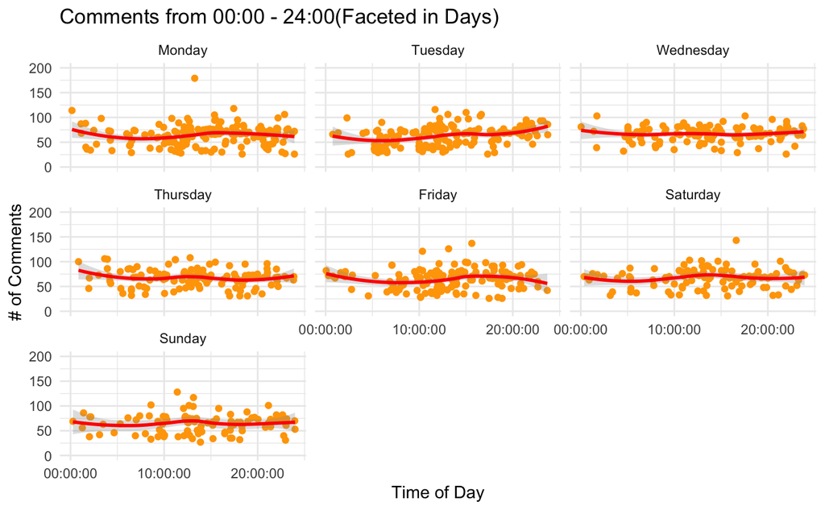

```r
comments_time
```

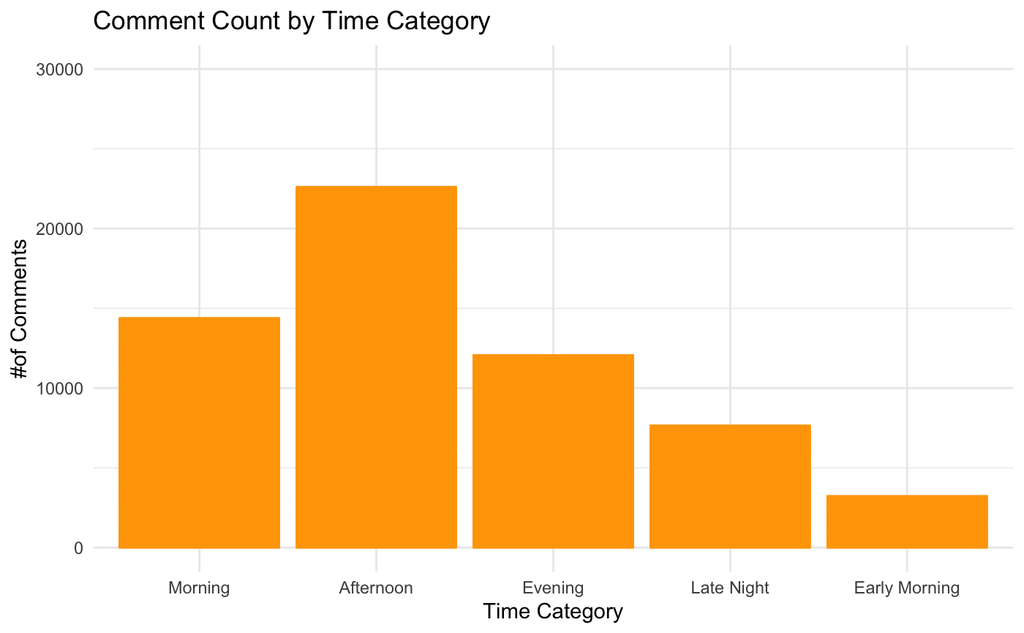

```r
#Factor so that the time_category is in time order
pre_training$time_category <- factor(pre_training$time_category,
                                   levels = c("Morning", "Afternoon",
                                              "Evening", "Late Night","Early Morning"))

#set a pipeline that has the comment frequency by time_category
pre_training %>%
  ggplot(aes(x = time_category, y = total_replies)) +
  geom_col(color ='orange',fill = 'orange') +
  labs(
    title = "Comment Count by Time Category",
    x = "Time Category",
    y = "#of Comments"
  ) +
  coord_cartesian(ylim = c(0, 30000)) +
  theme_minimal()
```

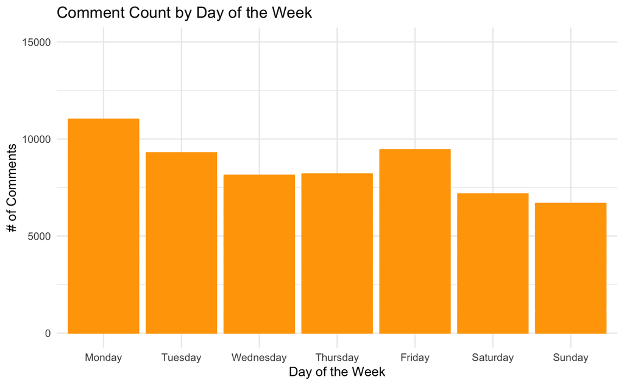

```r
pre_training$Day.of.Week <- factor(pre_training$Day.of.Week,
                                   levels = c("Monday", "Tuesday", "Wednesday",
                                              "Thursday", "Friday", "Saturday", "Sunday"))
#pipeline that showcases comment frequency by days
pre_training %>%
  ggplot(aes(x = Day.of.Week, y = total_replies)) +
  geom_col(color = 'orange',fill = 'orange') +
  labs(
    title = "Comment Count by Day of the Week",
    x = "Day of the Week",
    y = "# of Comments"
  ) +
  coord_cartesian(ylim = c(0, 15000)) +
  theme_minimal()
```

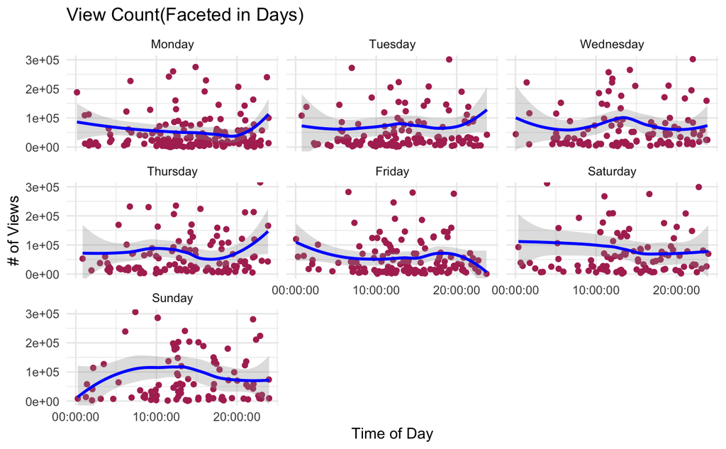

```r
#showcase post_time by View count with a loess line to visualize
#trend throughout the day
#facet this by days of the week
pre_training %>%
  ggplot(aes(x = post_time, y = View.Count)) +
  geom_point(color ="maroon") +
  geom_smooth(method = "loess", color = "blue", alpha = 0.3) +
  labs(
    title = "View Count(Faceted in Days)",
    x = "Time of Day",
    y = "# of Views"
  ) +
  coord_cartesian(ylim = c(0, 300000)) +
  theme_minimal() +
  facet_wrap(~ Day.of.Week)
```

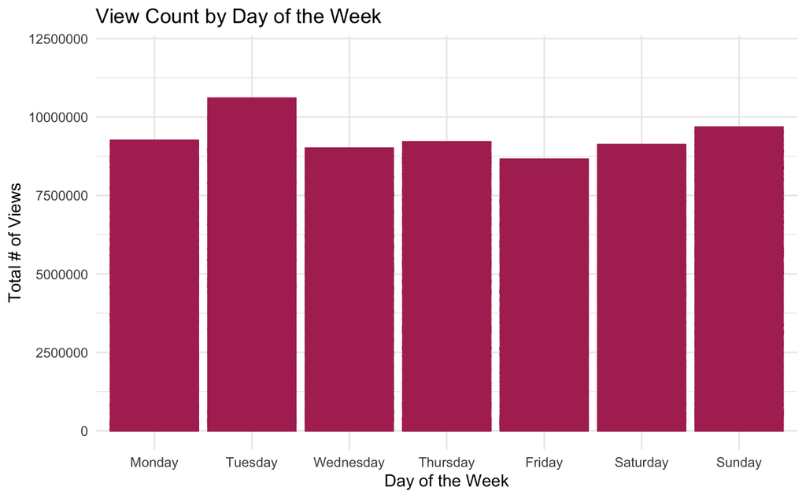

```r
pre_training$Day.of.Week <- factor(pre_training$Day.of.Week,
                                   levels = c("Monday", "Tuesday", "Wednesday",
                                              "Thursday", "Friday", "Saturday", "Sunday"))

#Frequency bar braph that showcases View Frequency by Days
pre_training %>%
  ggplot(aes(x = Day.of.Week, y = View.Count)) +
  geom_col(color = "maroon",fill = 'maroon') +
  labs(
    title = "View Count by Day of the Week",
    x = "Day of the Week",
    y = "Total # of Views"
  ) +
  coord_cartesian(ylim = c(0, 12000000)) +
  theme_minimal()
```

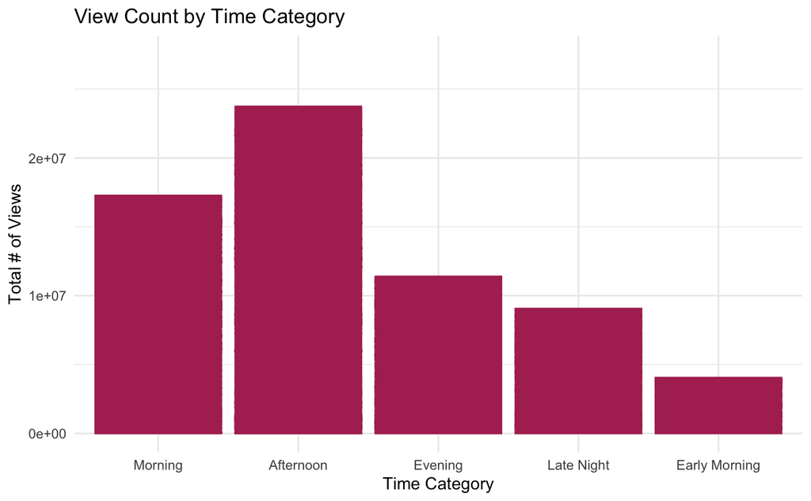

```r
#Showcases Viewcount frequency by time category
pre_training %>%
  ggplot(aes(x = time_category, y = View.Count)) +
  geom_col(color ='maroon',fill ='maroon') +
  labs(
    title = "View Count by Time Category",
    x = "Time Category",
    y = "Total # of Views"
  ) +
  coord_cartesian(ylim = c(0, 27500000)) +
  theme_minimal()
```

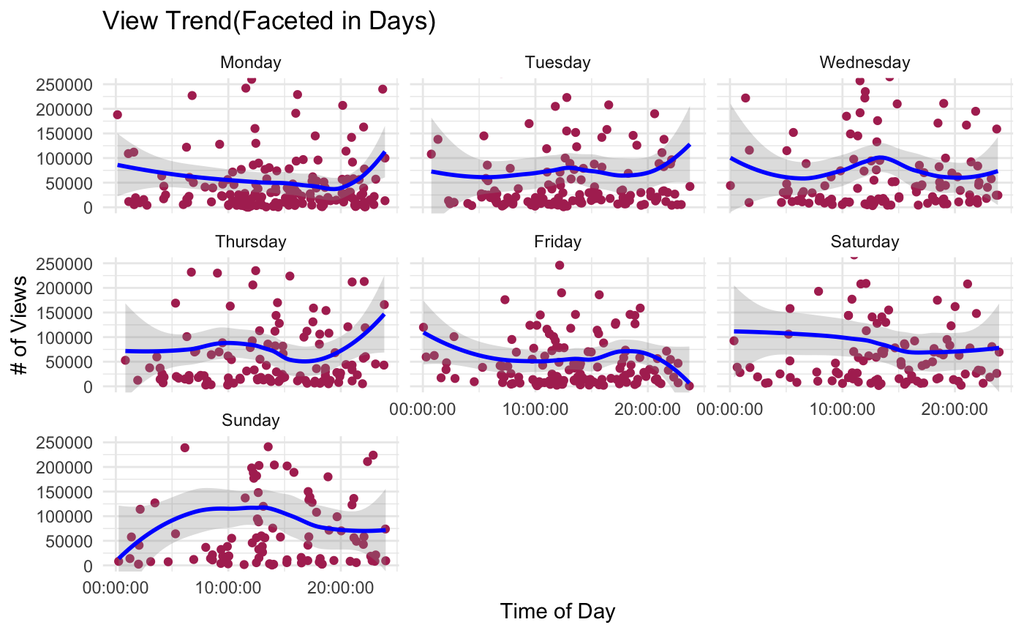

```r
#Facet by days
#Showcase the Likes trend throughout time
pre_training %>%
  ggplot(aes(x = post_time, y = View.Count)) +
  geom_point(color = "maroon") +
  geom_smooth(method = "loess", color = "blue", alpha = 0.3) +
  labs(
    title = "View Trend(Faceted in Days)",
    x = "Time of Day",
    y = "# of Views"
  ) +
  coord_cartesian(ylim = c(0, 250000)) +
  theme_minimal() +
  facet_wrap(~ Day.of.Week)
```

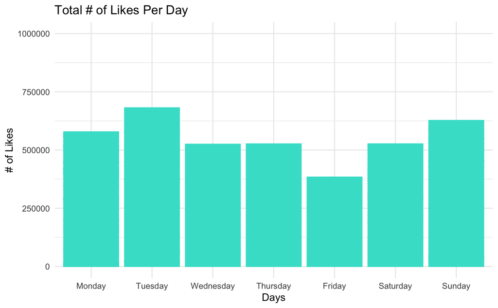

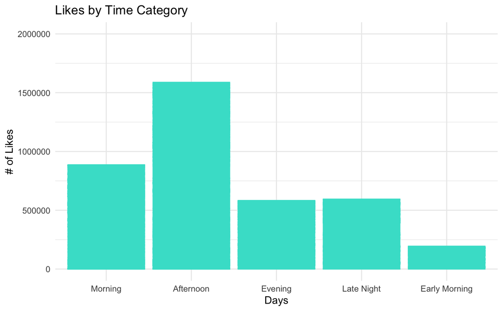

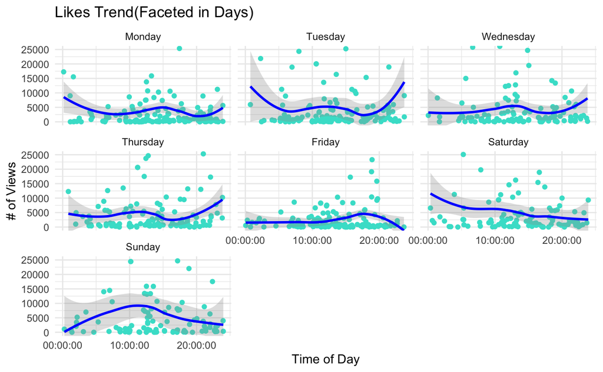

```r
pre_training %>%
  ggplot(aes(x = post_time, y = Likes)) +
  geom_point(color = "turquoise") +
  geom_smooth(method = "loess", color = "blue", alpha = 0.3) +
  labs(
    title = "Likes Trend(Faceted in Days)",
    x = "Time of Day",
    y = "# of Views"
  ) +
  coord_cartesian(ylim = c(0, 25000)) +
  theme_minimal() +
  facet_wrap(~ Day.of.Week)
```

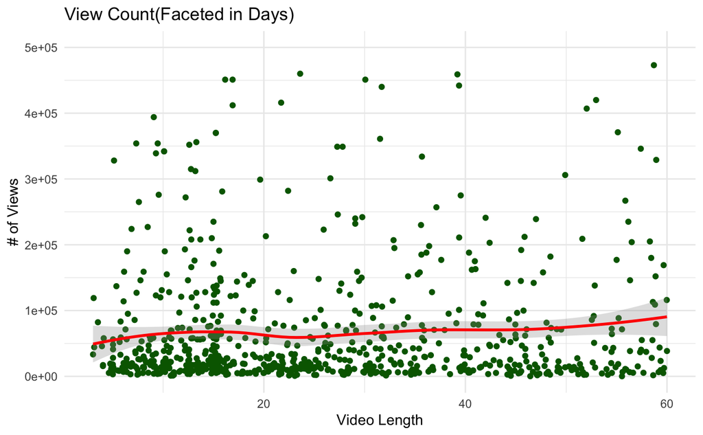

```r
pre_training %>%
  filter(v_length < 60  & View.Count < 500000) %>%
  ggplot(aes(x = v_length, y = View.Count)) +
  geom_point(color = "darkgreen") +
  geom_smooth(method = "loess", color = "red", alpha = 0.3) +
  labs(
    title = "View Count(Faceted in Days)",
    x = "Video Length",
    y = "# of Views"
  ) +
  coord_cartesian(ylim = c(0, 500000)) +
  theme_minimal()
```

#Step 2: Decision Tree/Probability With this project a decision tree was made combining categorical/numerical data and predicting the probability for the categorical and numerical values.

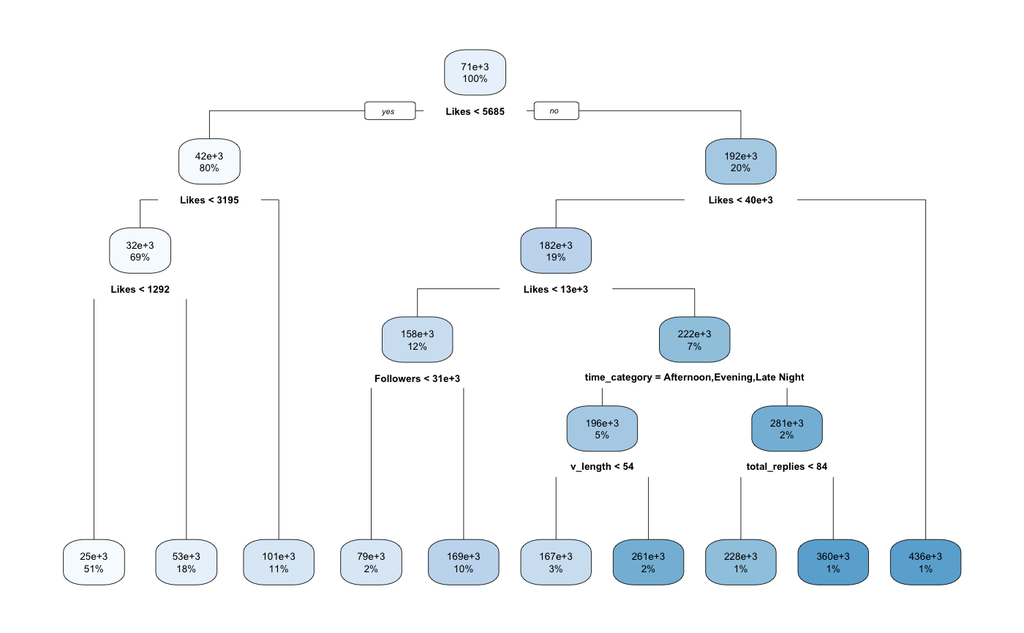

```
2.  Likes ≥ 3195:
```

The view count increases to 101k views suggests a strong correlation with likes and viewership.

The Right Branch (Likes ≥ 5685):

[output not shown]

Number of replies further influences views: If more than 84 replies: then View counts rise to 360k Less than 84 replies: view count is 228k

Conclusion:

The findings in this research partially supports the original hypothesis, as Monday and Tuesday emerged as days with highest engagement levels, though posting on Sunday afternoons would show promising potential to reach a broader audience as the video will have a good chance of spilling into the algorithm on the days where engagement is high.

Although there has been statistics that involves Likes, Comments, Time, Date, video length, this data can be expanded by utilizing API Keys or Appium to extract data such as Shares, Saves, Percentage of reach to followers to non-followers, Bonus rewards(monetization that one gets in relation to engagement and Views).